# STAT6180: Assignment (Semester 2)

Josiah Jackson

2023-10-09

## Question 1

1. Produce a plot and a correlation matrix of the data. Comment on possible relationships between the response and predictors and relationships between the predictors themselves

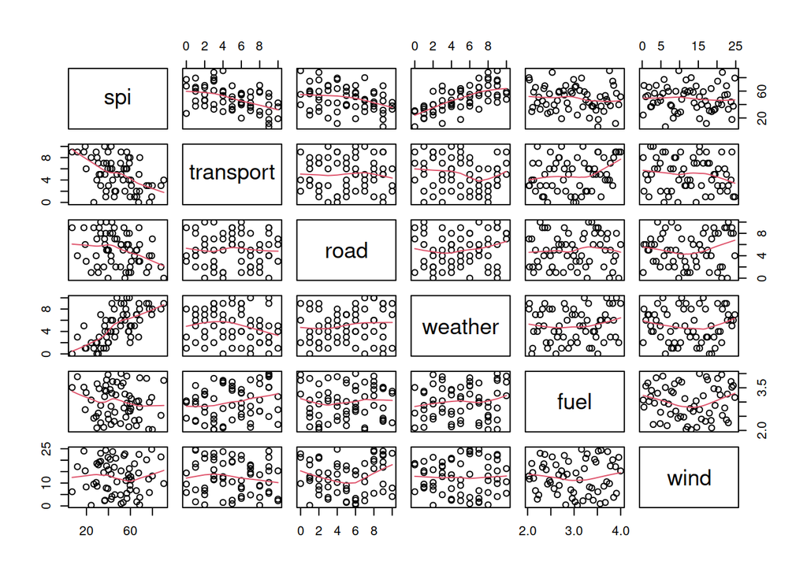

```r
# Import data and produce plot
traffic <- read.csv("data/traffic.csv", header = TRUE)
pairs(traffic, panel = panel.smooth)
```

Comments: We can observe a high correlation between spi and the variables transport and weather

```r
cor(traffic)
```

```
##                   spi    transport         road     weather         fuel
## spi        1.00000000 -0.472909967 -0.303836850  0.66672345 -0.138153417
## transport -0.47290997  1.000000000 -0.005714728 -0.16971072  0.240947972
## road      -0.30383685 -0.005714728  1.000000000  0.12495993  0.043675635
## weather    0.66672345 -0.169710717  0.124959926  1.00000000  0.110531767
## fuel      -0.13815342  0.240947972  0.043675635  0.11053177  1.000000000
## wind      -0.03466263 -0.131014749  0.080481857  0.00751783  0.006532832
##                   wind
## spi       -0.034662632
## transport -0.131014749
## road       0.080481857
## weather    0.007517830
## fuel       0.006532832
## wind       1.000000000
```

Comments: The correlation matrix shows high positive correlation between spi and weather, and moderate negative correlation with variables transport and road. Between the predictors, there is only a small positive correlation between transport and fuel.

2. Fit a model using all the predictors to explain the spi response. Then, using the full model, estimate the impact of weather on spi. Do this by producing a 95% confidence interval that quantifies the change in spi for every one index value increase of weather and comment.

```r
# Fit model using all predictors
spi.lm <- lm(spi ~ ., data = traffic)
summary(spi.lm)
```

```
##
## Call:
## lm(formula = spi ~ ., data = traffic)
##
## Residuals:
##      Min       1Q   Median       3Q      Max
## -18.1596  -4.9415   0.1278   5.1686  21.7415
##
## Coefficients:
##             Estimate Std. Error t value Pr(>|t|)
## (Intercept)  62.8071     7.4080   8.478 1.27e-11 ***
## transport    -2.1750     0.4611  -4.717 1.63e-05 ***
## road         -2.4097     0.4365  -5.520 9.04e-07 ***
## weather       4.2456     0.4473   9.492 2.92e-13 ***
## fuel         -3.6145     2.2759  -1.588    0.118
## wind         -0.1358     0.1764  -0.769    0.445
## ---
## Signif. codes:  0 '***' 0.001 '**' 0.01 '*' 0.05 '.' 0.1 ' ' 1
##
## Residual standard error: 9.913 on 56 degrees of freedom
## Multiple R-squared:  0.7405, Adjusted R-squared:  0.7174
## F-statistic: 31.96 on 5 and 56 DF,  p-value: 3.039e-15
```

$$\text{Regression Model: }
\hat{spi} = 62.8071 - 2.175 \times transport - 2.4097 \times road +
4.2456 \times weather - 3.6145 \times fuel - 0.1358 \times wind +
\varepsilon$$

```r
# Confidence interval to estimate the impact of weather on spi
b_humidity <- spi.lm$coefficients[4]
n <- nrow(traffic)
tquant <- qt(0.975, n - 2)
se_b_humidity <- summary(spi.lm)$coefficients[,2][4]

lower <- b_humidity - tquant * se_b_humidity
upper <- b_humidity + tquant * se_b_humidity

paste(lower, upper)
```

```
## [1] "3.35096433921561 5.14032296064003"
```

$$\beta weather \pm t \times s.e.(\beta weather) = 4.2456 \pm 2.0003
\times 0.4473 = (3.35096434, 5.14032296)$$

Comments: For each index value that weather increases, it is expected that the spi index value will increase between 3.351 and 5.140 values

3. Conduct an F-test for the overall regression (i.e. is there any relationship between the response and the predictors)

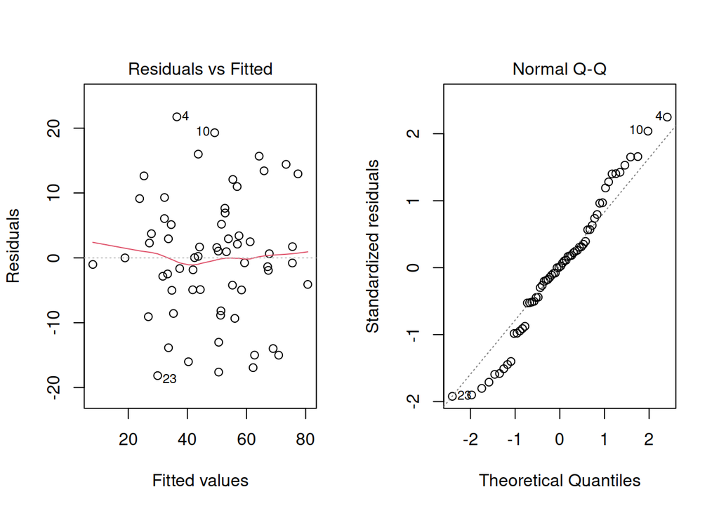

```r
# Check assumptions
par(mfrow = c(1, 2))
plot(spi.lm, which = 1:2)
```

Comments: The Residuals vs Fitted plot contains no discernible pattern, and the Normal Q-Q plot demonstrates a visible linear trend, indicating that the residuals are close to normally distributed. Constant variance and normality assumptions are therefore satisfied.

$$Multiple \space Regression \space Model: \hat{spi} = \beta 0 + \beta
1 \times transport + \beta 2 \times road + \beta 3 \times weather +
\beta 4 \times fuel + \beta 5 \times wind + ℇ$$

```r
# ANOVA table
spi.aov <- anova(spi.lm)
spi.aov
```

|  | Df | Sum Sq | Mean Sq | F value | Pr(>F) |
| --- | --- | --- | --- | --- | --- |
| transport | 1 | 4742.62547 | 4742.62547 | 48.2656238 | 4.228312e-09 |
| road | 1 | 1992.73106 | 1992.73106 | 20.2799922 | 3.440583e-05 |
| weather | 1 | 8651.93951 | 8651.93951 | 88.0506503 | 4.355062e-13 |
| fuel | 1 | 258.06862 | 258.06862 | 2.6263602 | 1.107205e-01 |
| wind | 1 | 58.17605 | 58.17605 | 0.5920568 | 4.448584e-01 |
| Residuals | 56 | 5502.61254 | 98.26094 | NA | NA |

```r
# Create reduced overall ANOVA table
reg_SS <- sum(spi.aov$`Sum Sq`)
reg_df <- 5
reg_MS <- reg_SS / reg_df
res_SS <- spi.aov$`Sum Sq`[6]
res_df <- 56
res_MS <- res_SS / res_df
Fobs <- reg_MS / res_MS
Pval <- pf(Fobs, reg_df, res_df, lower.tail = FALSE)

Pr_F <- 0
if (Pval < 0.000000001) {
  Pr_F = 0
} else {
  Pr_F = Pval
}

reduced_aov <- matrix(c(reg_df, reg_SS, reg_MS, Fobs, Pr_F,
                        res_df, res_SS, res_MS, NaN, NaN), ncol=5, byrow=TRUE)
colnames(reduced_aov) <- c('Df', 'Sum Sq', 'Mean Sq', 'F Value', 'Pr(>F)')
rownames(reduced_aov) <- c('Regression', 'Residuals')

reduced_aov
```

[output not shown]

Conclusion: Since the P-Value is significantly smaller than the level of significance, there is enough evidence to reject H<sub>0</sub>. This means that there is a significant linear relationship between spi and at least one of the five predictor variables

4. Validate the full model and comment on whether the full regression model is appropriate to explain the spi

```r
spi.aov
```

|  | Df | Sum Sq | Mean Sq | F value | Pr(>F) |
| --- | --- | --- | --- | --- | --- |
| transport | 1 | 4742.62547 | 4742.62547 | 48.2656238 | 4.228312e-09 |
| road | 1 | 1992.73106 | 1992.73106 | 20.2799922 | 3.440583e-05 |
| weather | 1 | 8651.93951 | 8651.93951 | 88.0506503 | 4.355062e-13 |
| fuel | 1 | 258.06862 | 258.06862 | 2.6263602 | 1.107205e-01 |
| wind | 1 | 58.17605 | 58.17605 | 0.5920568 | 4.448584e-01 |
| Residuals | 56 | 5502.61254 | 98.26094 | NA | NA |

Comments: Both the fuel and wind predictor variables both have P-Values of over 0.05, and are therefore insignificant. This means that it is not appropriate to use the full model to explain the spi. A new regression model without the fuel and wind variables will be used to proceed

```r
spi.lm2 <- lm(spi ~ transport + road + weather, data = traffic)
spi.aov2 <- anova(spi.lm2)
spi.aov2
```

|  | Df | Sum Sq | Mean Sq | F value | Pr(>F) |
| --- | --- | --- | --- | --- | --- |
| transport | 1 | 4742.625 | 4742.6255 | 47.27256 | 4.742398e-09 |
| road | 1 | 1992.731 | 1992.7311 | 19.86273 | 3.861551e-05 |
| weather | 1 | 8651.940 | 8651.9395 | 86.23901 | 4.480360e-13 |
| Residuals | 58 | 5818.857 | 100.3251 | NA | NA |

Comments: After removing the fuel and wind predictor variables, all the predictors in the new model are significant. This model is more appropriate to explain the spi.

5. Find the R<sup>2</sup> and comment on what it means in the context of this dataset

```r
summary(spi.lm)
```

```
##
## Call:
## lm(formula = spi ~ ., data = traffic)
##
## Residuals:
##      Min       1Q   Median       3Q      Max
## -18.1596  -4.9415   0.1278   5.1686  21.7415
##
## Coefficients:
##             Estimate Std. Error t value Pr(>|t|)
## (Intercept)  62.8071     7.4080   8.478 1.27e-11 ***
## transport    -2.1750     0.4611  -4.717 1.63e-05 ***
## road         -2.4097     0.4365  -5.520 9.04e-07 ***
## weather       4.2456     0.4473   9.492 2.92e-13 ***
## fuel         -3.6145     2.2759  -1.588    0.118
## wind         -0.1358     0.1764  -0.769    0.445
## ---
## Signif. codes:  0 '***' 0.001 '**' 0.01 '*' 0.05 '.' 0.1 ' ' 1
##
## Residual standard error: 9.913 on 56 degrees of freedom
## Multiple R-squared:  0.7405, Adjusted R-squared:  0.7174
## F-statistic: 31.96 on 5 and 56 DF,  p-value: 3.039e-15
```

R Squared: R<sup>2</sup> = SS(Regression) / SS(Total) = 15703.5/21206.1 = 0.7405

Comments: This significantly high R-squared value shows that the predictor variables in the original model contribute significantly to the spi

6. Using model selection procedures discussed in the unit, find the best multiple regression model that explains the data. State the final fitted regression model.

```r
summary(spi.lm)$coefficients
```

```
##               Estimate Std. Error    t value     Pr(>|t|)
## (Intercept) 62.8071258  7.4079572  8.4783327 1.270384e-11
## transport   -2.1750456  0.4611007 -4.7170731 1.634444e-05
## road        -2.4096862  0.4365099 -5.5203467 9.036105e-07
## weather      4.2456436  0.4472731  9.4922858 2.918068e-13
## fuel        -3.6145270  2.2759093 -1.5881682 1.178790e-01
## wind        -0.1357686  0.1764484 -0.7694523 4.448584e-01
```

```r
summary(spi.lm2)$coefficients
```

```
##              Estimate Std. Error   t value     Pr(>|t|)
## (Intercept) 51.737015  4.1026793 12.610543 2.909752e-18
## transport   -2.321620  0.4449080 -5.218204 2.535898e-06
## road        -2.456284  0.4394267 -5.589748 6.399379e-07
## weather      4.144978  0.4463447  9.286496 4.480360e-13
```

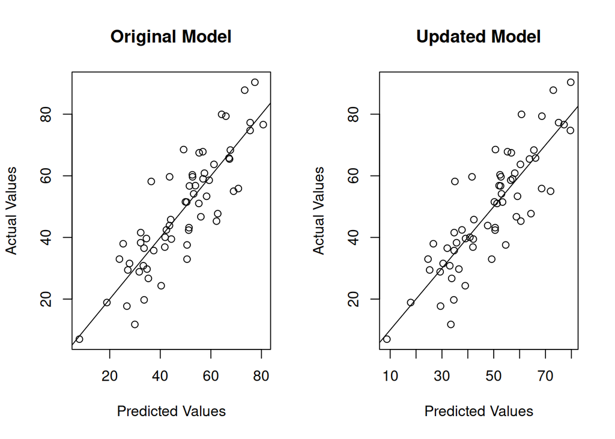

```r
par(mfrow = c(1, 2))
plot(x=predict(spi.lm), y=traffic$spi,
     xlab='Predicted Values',
     ylab='Actual Values',
     main='Original Model')
abline(a=0, b=1)

plot(x=predict(spi.lm2), y=traffic$spi,
     xlab='Predicted Values',
     ylab='Actual Values',
     main='Updated Model')
abline(a=0, b=1)
```

7. Comment on the R2 and adjusted R2 in the full and final model you chose in part f. In particular explain why those goodness of fitness measures change

```r
summary(spi.lm2)
```

```
##
## Call:
## lm(formula = spi ~ transport + road + weather, data = traffic)
##
## Residuals:
##     Min      1Q  Median      3Q     Max
## -21.672  -5.643   1.067   4.656  23.164
##
## Coefficients:
##             Estimate Std. Error t value Pr(>|t|)
## (Intercept)  51.7370     4.1027  12.611  < 2e-16 ***
## transport    -2.3216     0.4449  -5.218 2.54e-06 ***
## road         -2.4563     0.4394  -5.590 6.40e-07 ***
## weather       4.1450     0.4463   9.286 4.48e-13 ***
## ---
## Signif. codes:  0 '***' 0.001 '**' 0.01 '*' 0.05 '.' 0.1 ' ' 1
##
## Residual standard error: 10.02 on 58 degrees of freedom
## Multiple R-squared:  0.7256, Adjusted R-squared:  0.7114
## F-statistic: 51.12 on 3 and 58 DF,  p-value: 2.724e-16
```

R Squared: R<sup>2</sup> = SS(Regression) / SS(Total) = 15387.2/21206.1 = 0.7256